# R Notebook Lab-2

# Basic simulation

General rule for simulation —-

p – p is short for probability, ‘p’ is used for getting distribution function value Pr( X<= p)

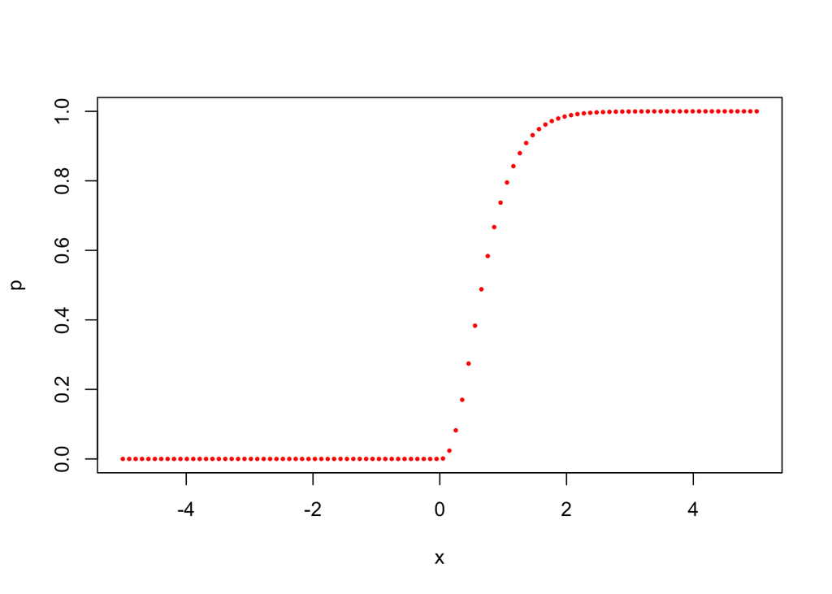

```r
x<- seq(-5,5,length.out = 100)
p<- pgamma(x,shape = 3,scale = 1/4)
plot(x,p,pch=16,cex=.5,col="red")
```

q – q is short for quantile, ‘q’ is used for getting quantiles.

```r
q1<- qnorm(.975)
q1
```

```
[1] 1.959964
```

```r
q2<- qnorm(.025)
q2
```

```
[1] -1.959964
```

r – r is short for random, ‘r’ is used for simulating from distribution.

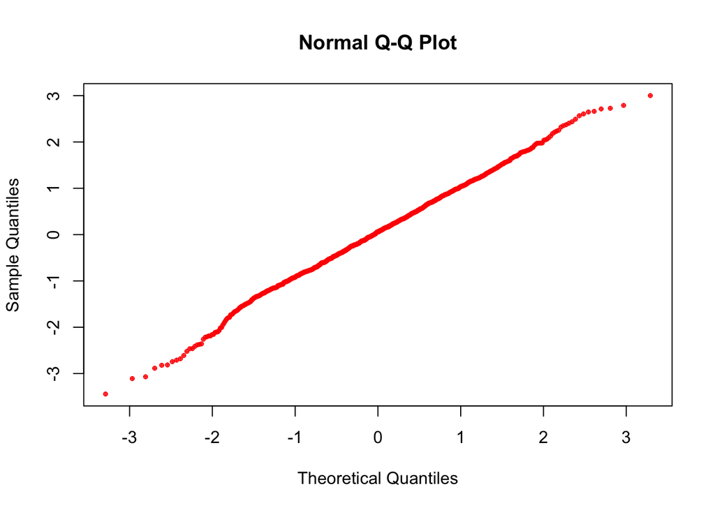

```r
x<- rnorm(1000);
qqnorm(x,col="red",pch=10,cex=.5)
```

d – d is short for density, ‘d’ is used for getting density of a probability distribution

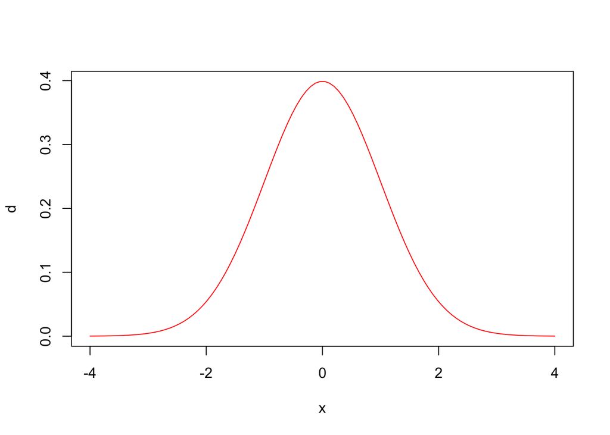

```r
x<- seq(-4,4,length.out = 100)
d<- dnorm(x)
plot(x,d,col="red",pch=16, ty='l')
```

Problems for Lab:

1. Simulate 1000 observation from Normal(3,4), Gamma(3,1/4), Exp(.3), Cauchy(3,5), t(df=5) , chi-sq(df = 5 ), plot their histograms.

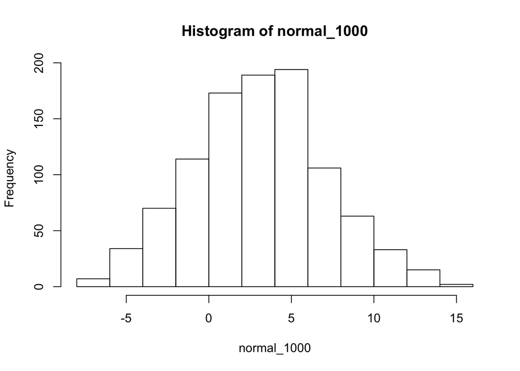

```r
# what is qqnorm?
normal_1000 = rnorm(1000, 3, 4) # sd should be 4 or 2?
hist(normal_1000)
```

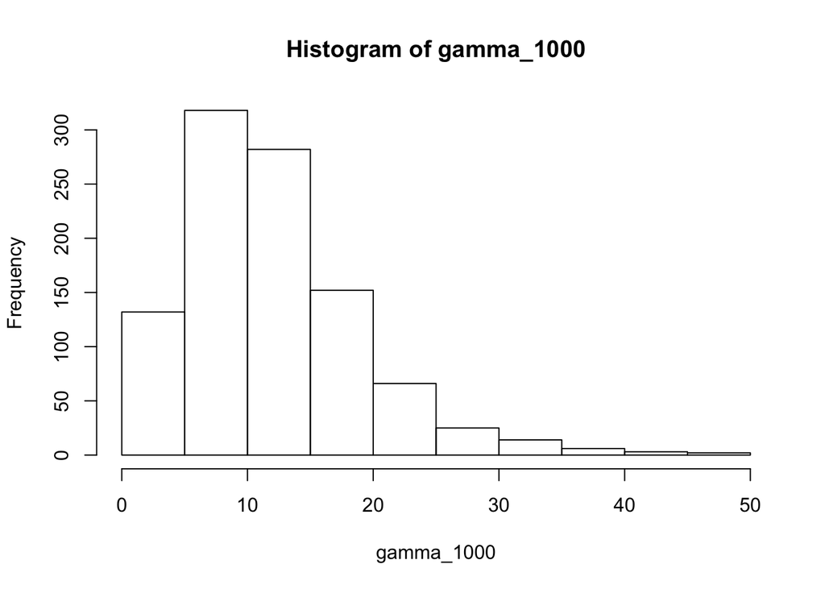

```r
gamma_1000 = rgamma(1000, 3, 1/4)
hist(gamma_1000)
```

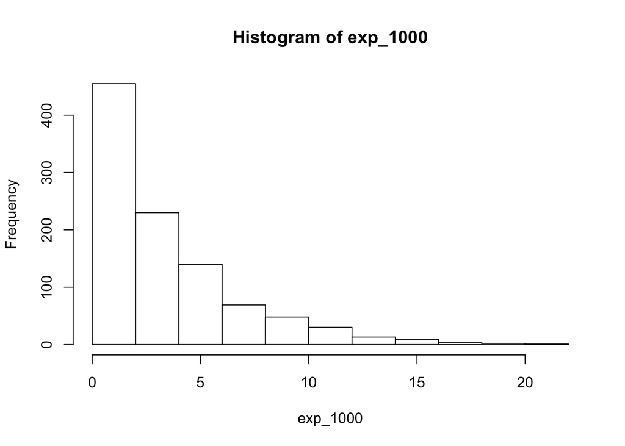

```r
exp_1000 = rexp(1000, 0.3)
hist(exp_1000)
```

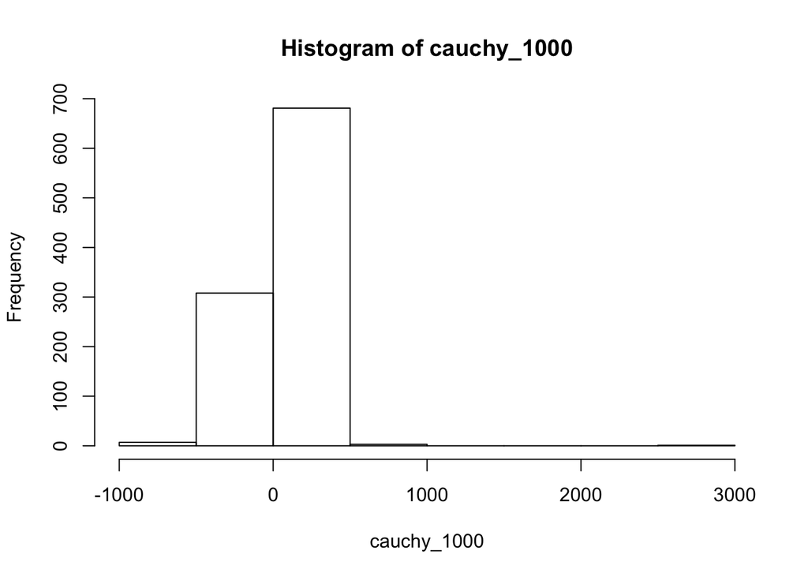

```r
cauchy_1000 = rcauchy(1000, 3, 5)
hist(cauchy_1000)
```

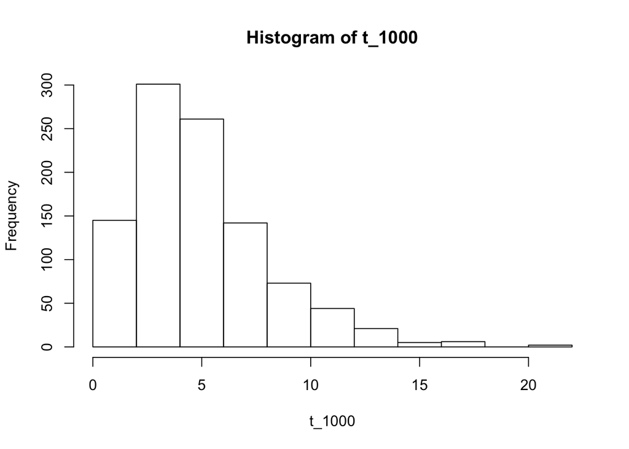

```r
t_1000 = rchisq(1000, df = 5)
hist(t_1000)
```

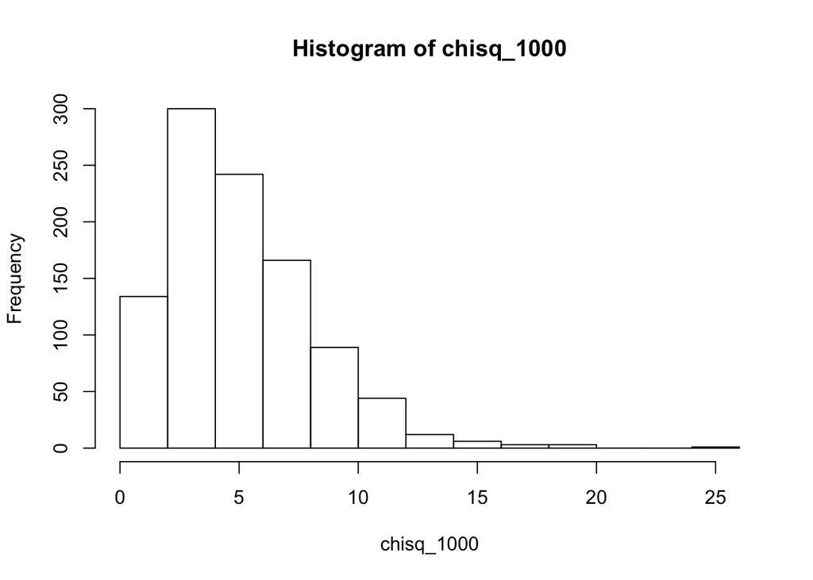

```r
chisq_1000 = rchisq(1000, df = 5)
hist(chisq_1000)
```

2. Find 2.5% and 97.5% quantiles for the above distributions.

```r
norm_quantile_2.5 = qnorm(0.025, 3, 4)

norm_quantile_97.5 = qnorm(0.975, 3, 4)

gamma_quantile_2.5 = qgamma(0.025, 3, 1/4)

gamma_quantile_97.5 = qgamma(0.975, 3, 1/4)

exp_quantile_2.5 = qexp(0.025, 0.3)

exp_quantile_97.5 = qexp(0.975, 0.3)

cauchy_quantile_2.5 = qcauchy(0.025, 3, 5)

cauchy_quantile_97.5 = qcauchy(0.975, 3, 5)

t_quantile_2.5 = qt(0.025, df = 5)

t_quantile_97.5 = qt(0.975, df = 5)

chisq_quantile_2.5 = qchisq(0.025, df = 5)

chisq_quantile_97.5 = qchisq(0.975, df = 5)
```

3. Plot density for Normal(3,4), Gamma(3,1/4), Exp(.3), use - ‘d’

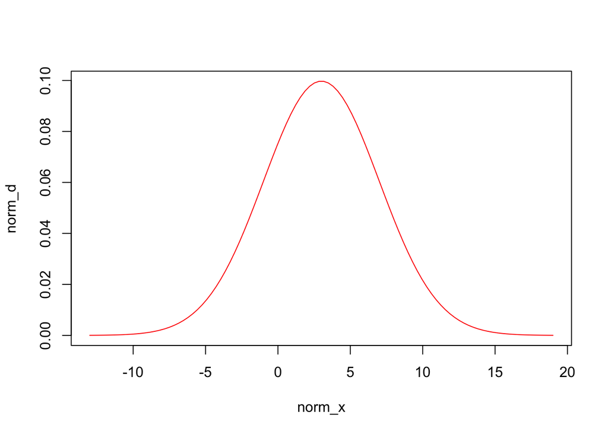

```r
norm_x = seq(-13, 19, length.out = 100)
norm_d = dnorm(norm_x, 3, 4)
plot(norm_x, norm_d, col="red", pch=16, ty="l")
```

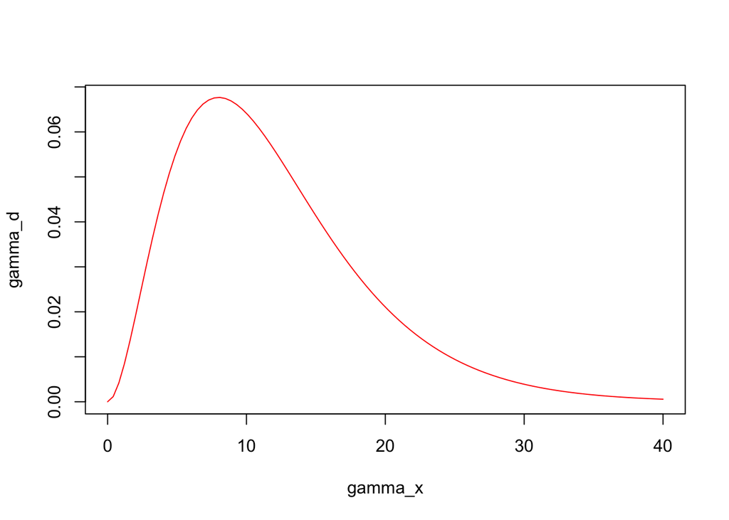

```r
gamma_x = seq(0, 40, length.out = 100)
gamma_d = dgamma(gamma_x, 3, 1/4)
plot(gamma_x, gamma_d, col="red", pch=16, ty="l")
```

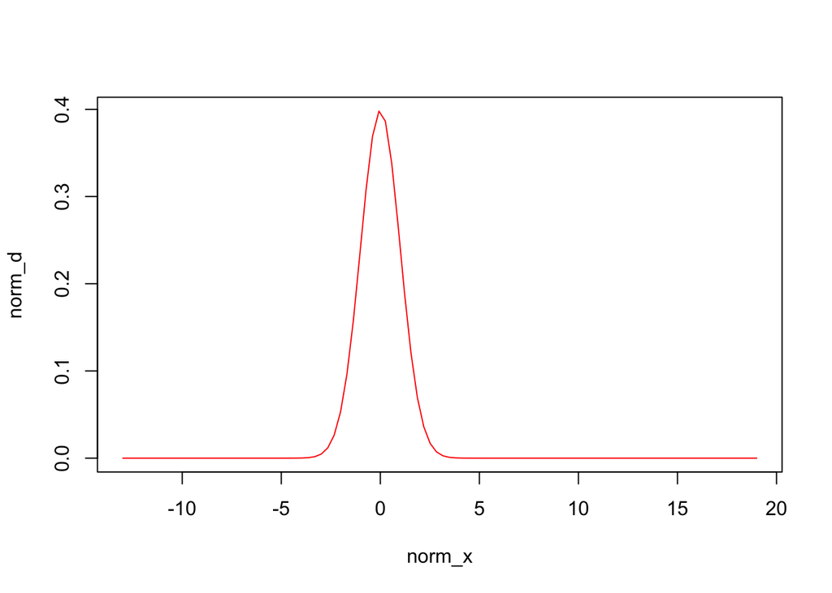

```r
exp_x = seq(-4, 4, length.out = 100)
norm_d = dnorm(norm_x)
plot(norm_x, norm_d, col="red", pch=16, ty="l")
```

4. Plot Distribution function for Normal(3,4), Gamma(3,1/4), Exp(.3) , use – ‘p’

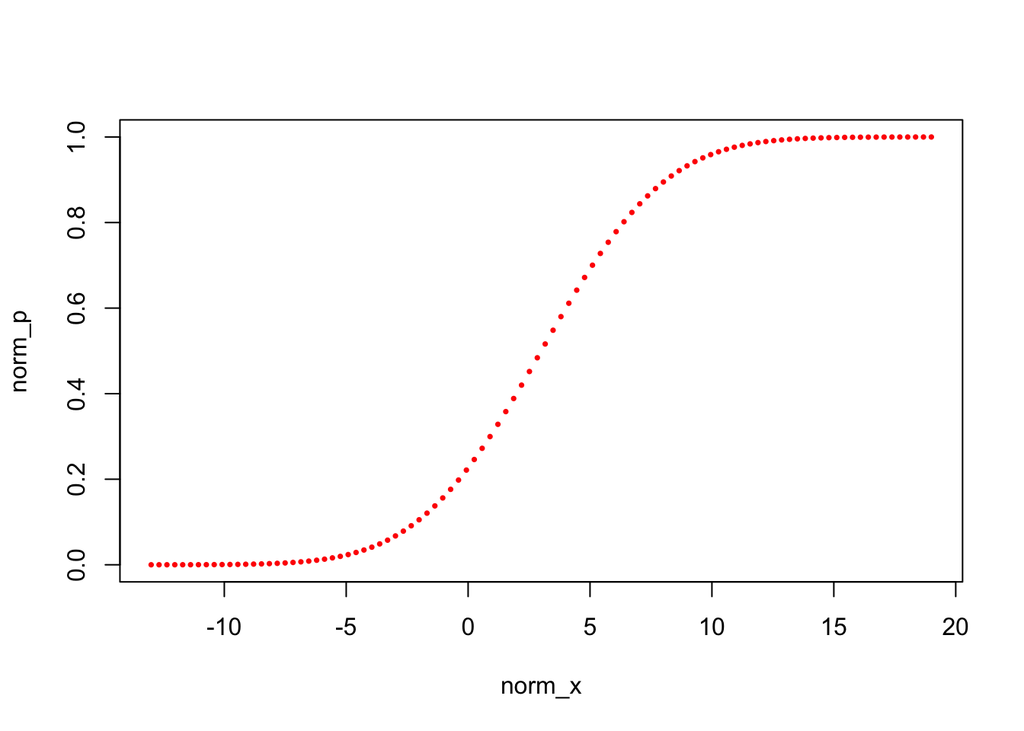

```r
norm_x = seq(-13, 19, length.out = 100)
norm_p = pnorm(norm_x, mean = 3, sd = 4)
plot(norm_x, norm_p, pch = 16, cex = 0.5, col = "red")
```

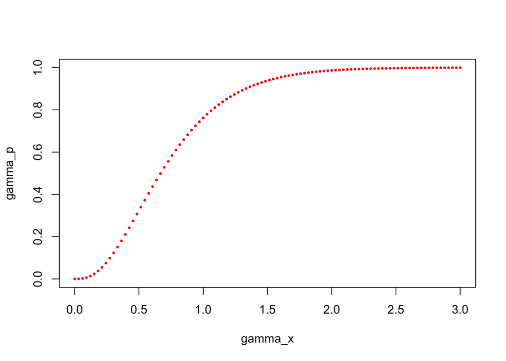

```r
gamma_x = seq(0, 3, length.out = 100)
gamma_p = pgamma(gamma_x, shape = 3,scale = 1/4)
plot(gamma_x, gamma_p, pch=16, cex=.5, col="red")
```

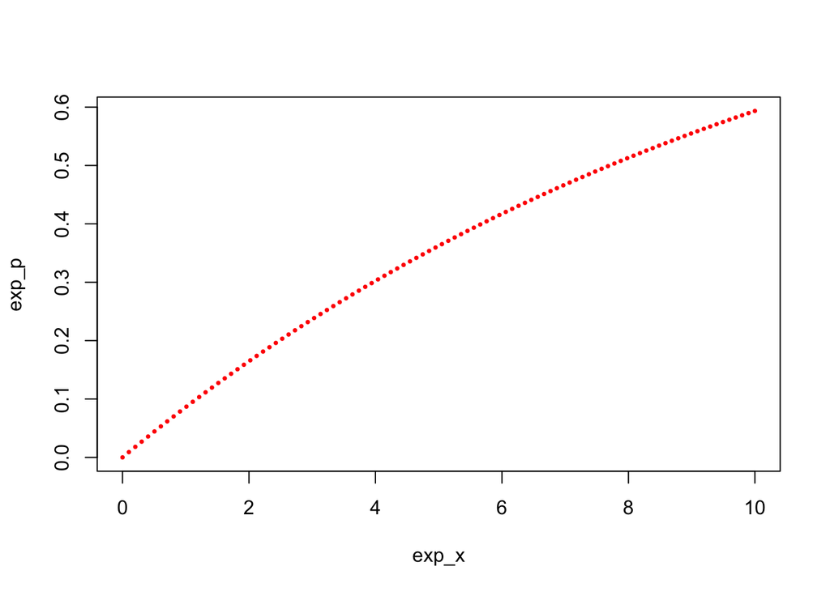

```r
exp_x = seq(0, 10, length.out = 100)
exp_p = pexp(gamma_x, 0.3)
plot(exp_x, exp_p, pch=16, cex=.5, col="red")
```

———————— Simulation data from an actual linear model ———————-

– generate x by seq(0,15,length.out = 30);

```r
x = seq(0, 15, length.out = 30)
```

– replicate x 6 times and store it in new_x, – use rep(x,6)

```r
new_x = rep(x, 6)
```

– Generate y by y = 2+3*x

```r
# variance is 3^2 = 9
y = 2 + 3*new_x
```

– add Gaussian noise to y ( sd = 3.5)

```r
y = y + rnorm(length(y), mean = 0, sd = 3.5)
```

– plot x vs y

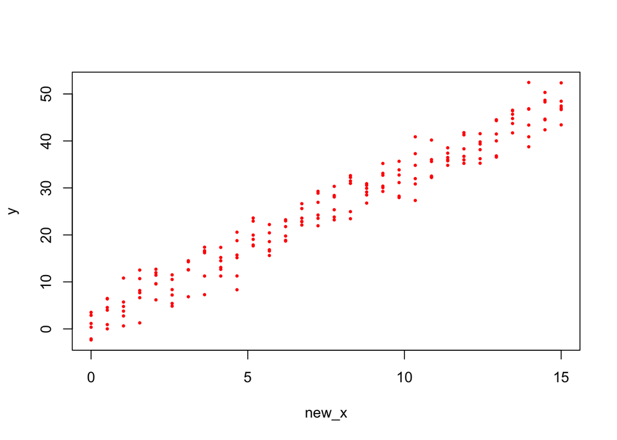

```r
plot(new_x, y, pch = 16, cex = 0.5, col = "red")
```

# Common data distribution

— Show positively skew example -> use log transformation

Positively skewed: (Q3 - median)/(median - Q1) >> 1 Negatively skewed: (Q3 - median)/(median - Q1) << 1 Normal: (Q3 - median)/(median - Q1) = 1

For log transformation, will decrease large data value very fast log(1) = 0 log(10) = 1 log(100) = 2 log(1000) = 3

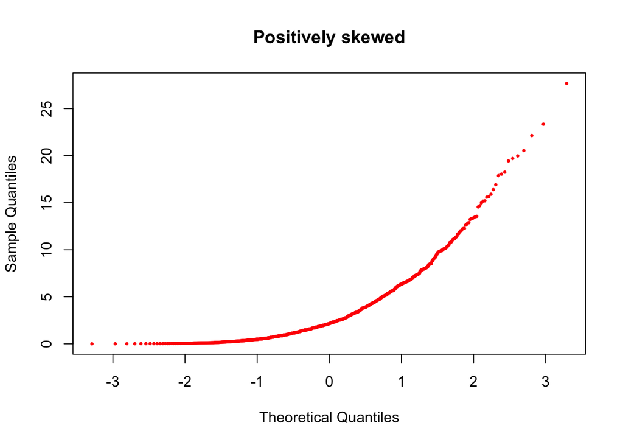

```r
y = rexp(1000, rate = 0.3)
qqnorm(y, main="Positively skewed", col="red", pch=16, cex=0.5)
```

1. Give an distribution of Thick tail distribution .

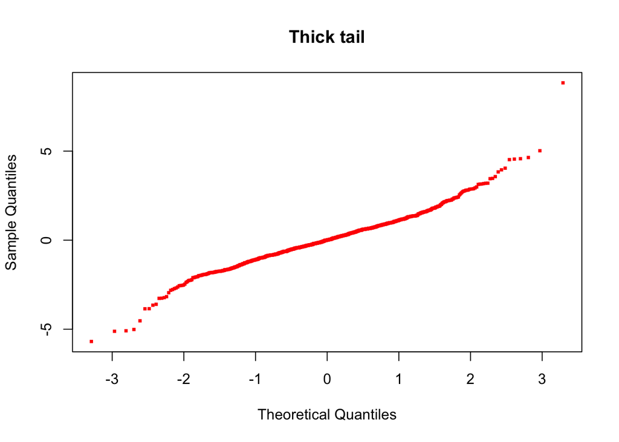

```r
y = rt(1000, df = 5)
qqnorm(y, main="Thick tail", col="red", pch=15, cex=0.5 )
```

2. Simulate from it .
3. Generate qqplot, histogram
4. What about thin tail distributions ?
2. Simulate from it .
3. Generate qqplot and box plot .

# Transformation with real data .

—– Example 1: Emission data

The data consists of the emissions of three different pollutants from 46 different engines.

```r
engine = read.csv("~/Desktop/STAT 151A/STAT-151A/lab/lab2/table_7_3.csv", sep=",", head = TRUE)
names(engine)
```

```
[1] "en"  "hc"  "co"  "nox"
```

[output not shown]

```r
summary(engine)
```

```
       en              hc               co              nox
 Min.   : 1.00   Min.   :0.3400   Min.   : 1.850   Min.   :0.490
 1st Qu.:12.75   1st Qu.:0.4375   1st Qu.: 4.388   1st Qu.:1.110
 Median :24.50   Median :0.5100   Median : 5.905   Median :1.315
 Mean   :24.00   Mean   :0.5502   Mean   : 7.879   Mean   :1.340
 3rd Qu.:35.25   3rd Qu.:0.6025   3rd Qu.:10.015   3rd Qu.:1.495
 Max.   :46.00   Max.   :1.1000   Max.   :23.530   Max.   :2.940
```

We will be analyzing the carbon-monoxide data here. Lets see if the data is skewed or not ?

1. Calculate the (q3-median)/(median-q1).

At first glance the carbon monoxide data appears to be skewed, because the spread between the third quantile and the max is five times the spread between the min and the first quantile.

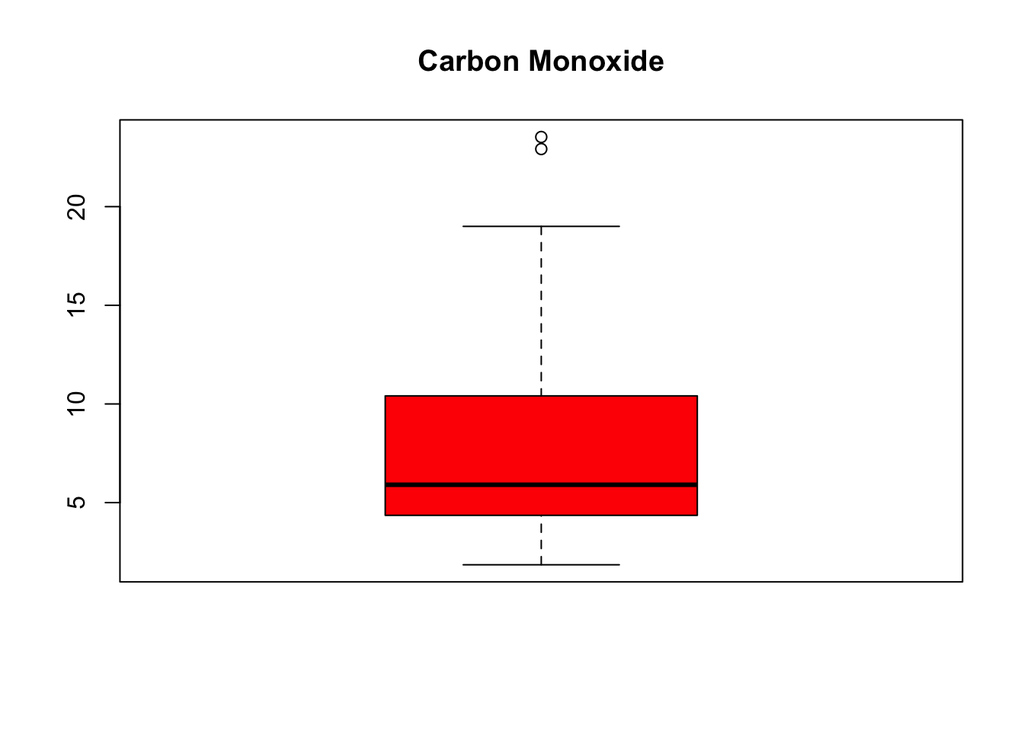

```r
co = (10.015 - 5.905)/(5.905 - 4.388)
# co = 2.7
# the distribution is positively skewed
boxplot(engine$co, main= "Carbon Monoxide", col = "red")
```

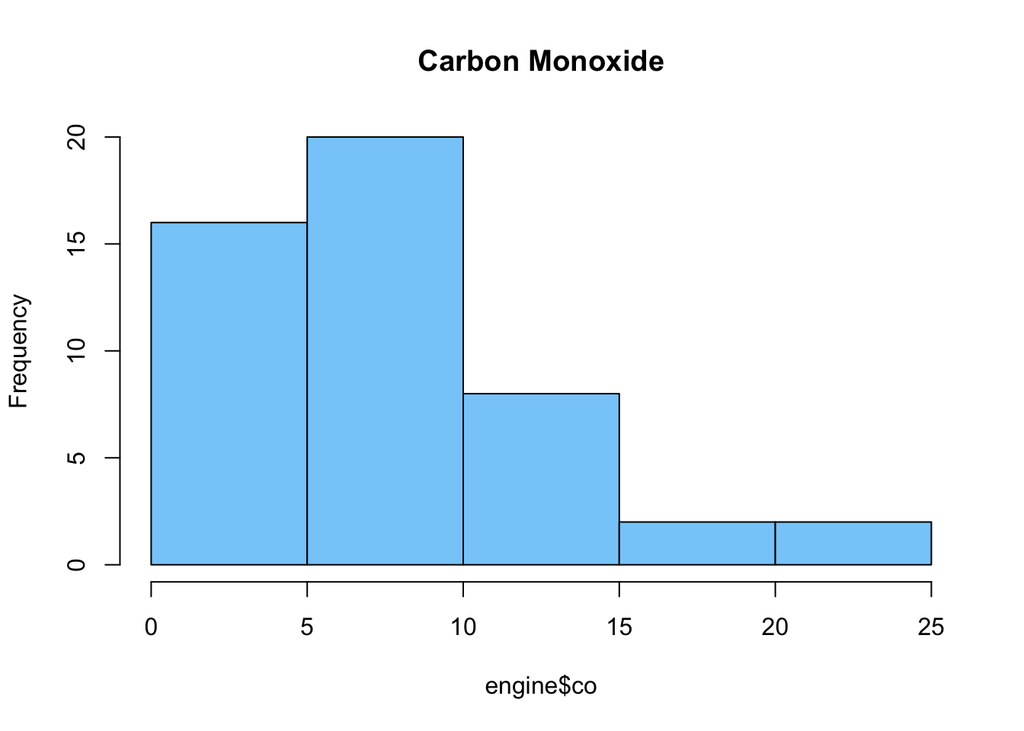

```r
hist(engine$co, main = "Carbon Monoxide", col = "lightskyblue", breaks = 6)
```

So, all the tools suggests that the carbon monoxide data is right skewed.

What can we do about it ? Lets try some transformations.

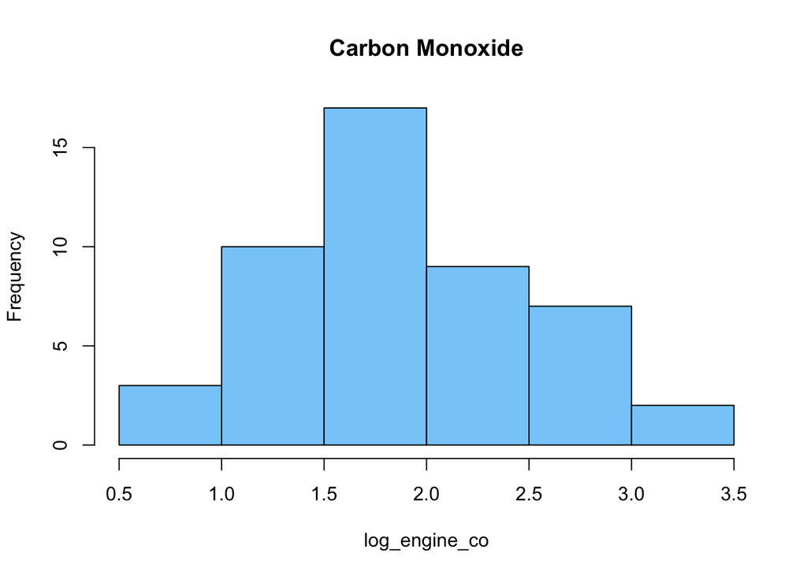

```r
log_engine_co = log(engine$co)
hist(log_engine_co, main = "Carbon Monoxide", col = "lightskyblue")
```

Data is rightly skewed, so lets log-transformation is a good option. ( Why ? )

# Example 2:

Import and GDP

1. Load data
2. See summary data.
3. Calculate (q3-q2)/(q2-q1) for IMPORT and GDP
4. Lets look at the histograms , qqplots and box-plots .

```r
trade = read.csv("~/Desktop/STAT 151A/STAT-151A/lab/lab2/imports.csv")
summary(trade)
```

```
      Country      IMPORTS             GDP
 Argentina: 1   Min.   :   0.17   Min.   :    0.618
 Australia: 1   1st Qu.:   4.80   1st Qu.:   21.400
 Bolivia  : 1   Median :  31.80   Median :  200.000
 Brazil   : 1   Mean   : 124.82   Mean   :  969.993
 Canada   : 1   3rd Qu.: 164.00   3rd Qu.:  923.000
 Cuba     : 1   Max.   :1148.00   Max.   :10082.000
 (Other)  :19
```

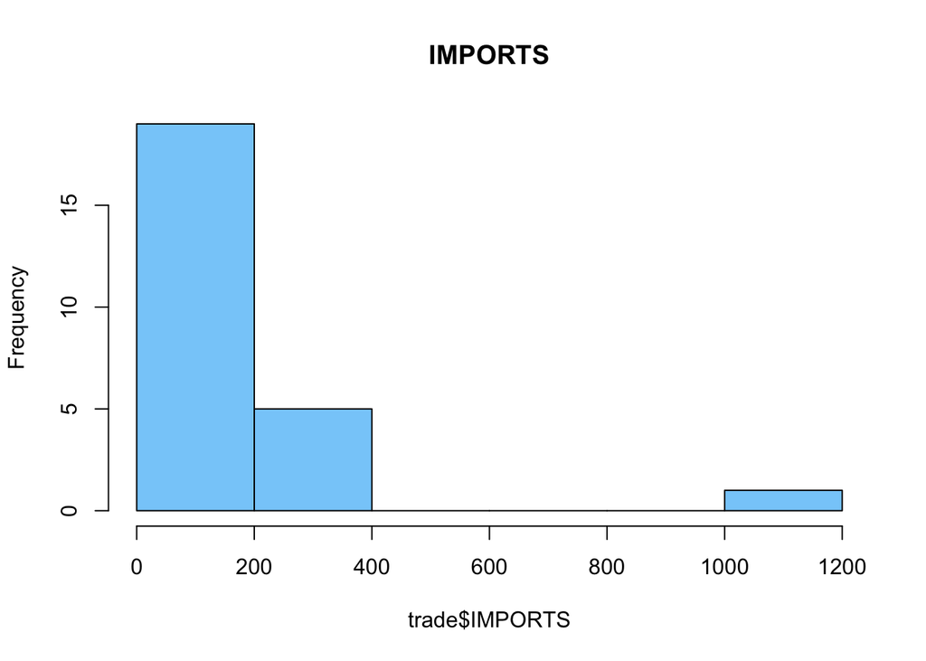

```r
# (Q3 - Q2) / (Q2 - Q1)


IMPORTS = (164 - 31.8)/(31.8-4.8)
# Since ratio >> 1
# input dataset is highly positive skewed

GDP = (923 - 200)/(200-21.4)
# Since ratio >> 1
# input dataset is highly positive skewed

hist(trade$IMPORTS, main="IMPORTS", col = "lightskyblue")
```

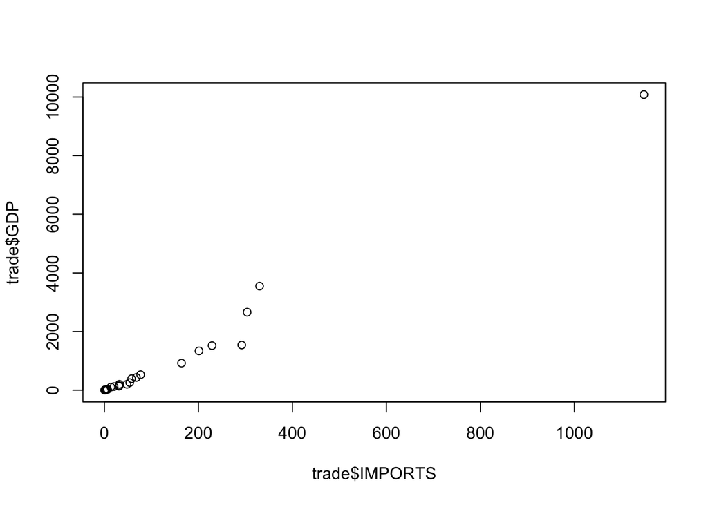

```r
qqplot(trade$IMPORTS, trade$GDP)
```

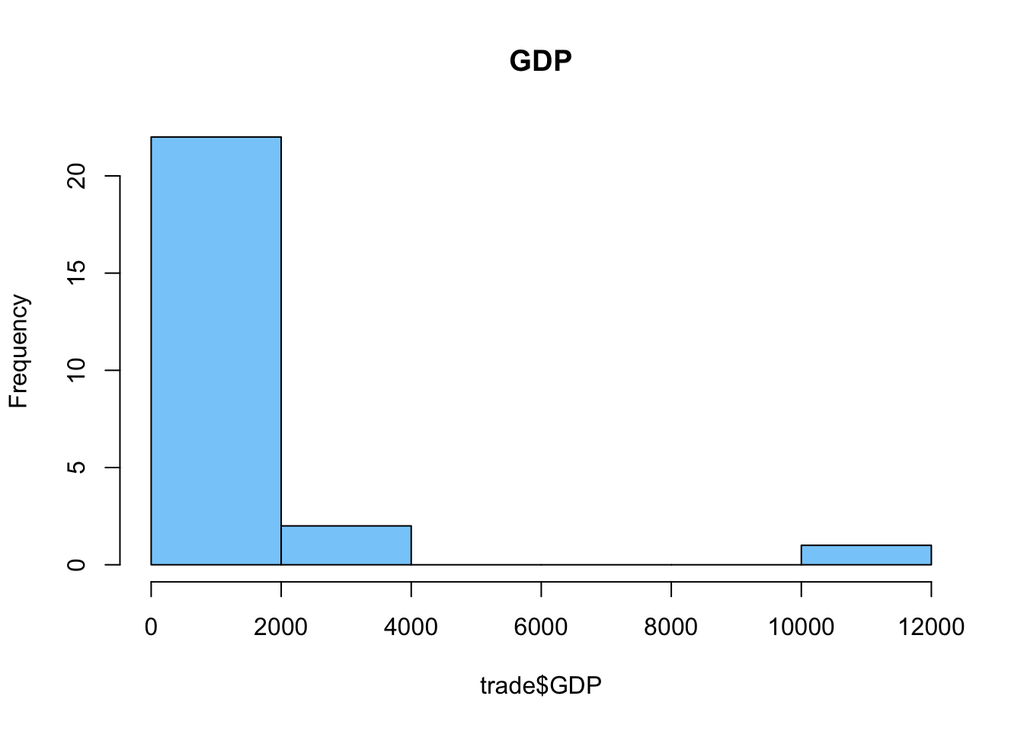

```r
hist(trade$GDP, main="GDP", col = "lightskyblue")
```

5. What do we see ? —- Both x and y are highly positively skewed .

What transform to use – Any suggestions ?

Use Logrithm transformation on both IMPORTS and GDP.

```r
log_import = log(trade$IMPORTS)
log_GDP = log(trade$GDP)
```

6. Plot the histogram for the transformed data ? How does it look ?
7. Plot Import vs GDP ( after transformation ).

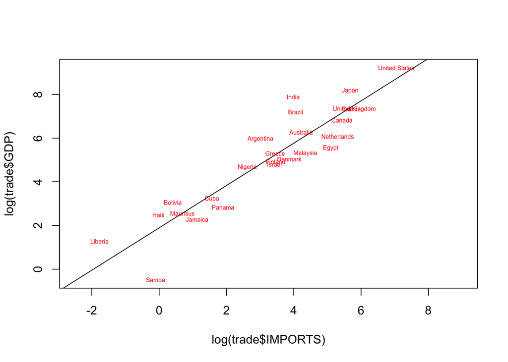

```r
plot(log(trade$IMPORTS), log(trade$GDP), col = 0, xlim = c(-2.5, 9))
text(log(trade$IMPORTS),  log(trade$GDP), labels = trade$Country, cex=0.5, col = "red")
model = lm( log(trade$GDP) ~ log(trade$IMPORTS))
abline(model)
```

# Example 3:

Variance Stabilization

—( Discuss the same variance assumption )

1. Load pickup data .
2. Remove all data before 1993 and for the remaining data plot pickup vs price.
3. What do you see – are variances are same across y-values ( price ) .
4. What transform to use ?
5. Apply the transform and then then plot again the dataset ?